# Some data is null since for all coulmns the count is not 2199.

# From the above graphs, we observed that following have:

- Normal Distribution curve
  - year
  - Life Ladder
    - Analysis: Most people from the dataset shows more than average rate of life ladder (best possible life for you) which is lifeLadder > 4.5
  - Log GDP per Capita
    - Analysis:Most people live in countries where log GDP per capita > 9.This is as expected from human tendency to live where GDP is high.
  - Generosity
  - Positive Effect
  - Negative effect
    - Both Positive and negative effect, we see people having maximun positive effect are equal to number of people having maximum negative effect
- Power-Law Distribution curve
  - Social Support
  - Healthy Life expectancy at birth
  - Freedom to make life choices
  - Perception of corruption
    - Analysis:We observe that social support, life expectancy and freedom to make choices are quite high than. expected. For perceptions of corruption, the count of number of people is also higher
1. Are there any interesting correlations in the data?

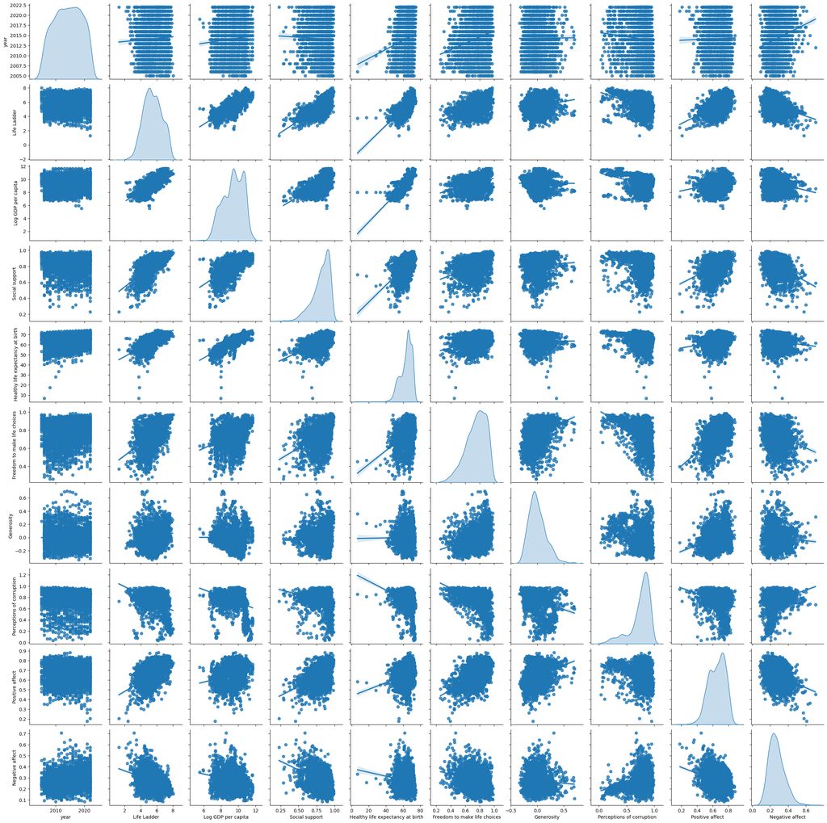

```python
sns.pairplot(numerical_columns, diag_kind='kde', kind='reg')
```

- The above pairplot suggests that higher degree of corruption detoriates the positive effect. It is also affecting negatively on freedom to make life choices. Thus overall negatively inducing happiness score.
- Countries that have freedom to make life choices have good social support from the government.
- Social Support, Good Log GDP per capita have positive effects on life ladder score.

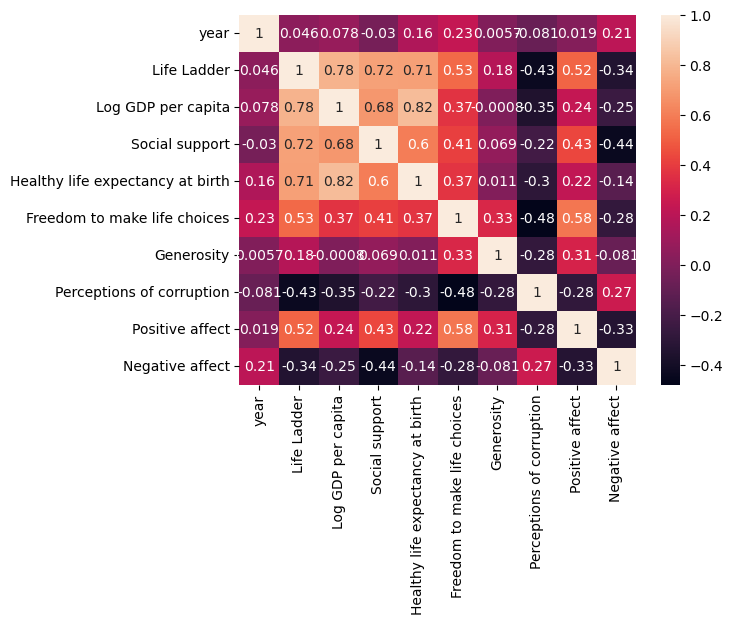

```python
sns.heatmap(numerical_columns.corr(), annot = True)
```

Analysis: Following are the observations:

- The heatmap shows that happier people (high life ladder score) are living in countries with high log GDP per capita, better social support and healthy life expectancy at birth.
- We see a strong correlation between high expectancy at birth and Log GDP per capita, that is, countries with High GDP per capita have good healthy life expectancy at birth.
- We see that generosity in people has negligible relationship to Log GDP per capita of the country which is expected.
- It is seen that countries with higher corruption are negatively correlated with life ladder/happiness score meaning that countries with higher corruption have lower happiness scores.
1. Can you identify any limitations, missing values or distortions of the data?

```python
missing_values
```

```
Country name                          0
year                                  0
Life Ladder                           0
Log GDP per capita                   20
Social support                       13
Healthy life expectancy at birth     54
Freedom to make life choices         33
Generosity                           73
Perceptions of corruption           116
Positive affect                      24
Negative affect                      16
dtype: int64
```

Yes there are missing values observed in dataset as we see above.

1. What would you like to see in this dataset?
- Census information(Population diversity): Population count
- Employment data
- Education data
- Country Size

What is the happiest country in 2022?

```python
df_2022 = df[df['year'] == 2022]
happiest_Country_22 = df_2022.loc[df_2022['Life Ladder'].idxmax()]['Country name']
print("Happiest country in 2022: ", happiest_Country_22)
```

```
Happiest country in 2022:  Finland
```

What is the happiest country in 2013?

```python
df_2013 = df[df['year'] == 2013]
happiest_Country_13 = df_2013.loc[df_2013['Life Ladder'].idxmax()]['Country name']
print("Happiest country in 2013: ", happiest_Country_13)
```

```
Happiest country in 2013:  Canada
```

What is the happiest country of all time?

```python
happiest_Country = df.loc[df['Life Ladder'].idxmax()]['Country name']
print("Happiest country of all time: ", happiest_Country)
```

```
Happiest country of all time:  Denmark
```

What is the least happiest country in 2022 ?

```python
least_happy_22 = df_2022.loc[df_2022['Life Ladder'].idxmin()]['Country name']
print("Least Happiest country in 2022: ", least_happy_22)
```

```
Least Happiest country in 2022:  Afghanistan
```

What is the leats happiest country in 2013?

```python
least_happy_13 = df_2013.loc[df_2013['Life Ladder'].idxmin()]['Country name']
print("Least Happiest country in 2013: ", least_happy_13)
```

```
Least Happiest country in 2013:  Syria
```

What is the least happiest country of all time?

```python
least_happiest = df.loc[df['Life Ladder'].idxmin()]['Country name']
print("Least Happiest country of all time: ", least_happiest)
```

```
Least Happiest country of all time:  Afghanistan
```

```python
df['Happiness Increase'] = df['Life Ladder'] - df.groupby('Country name')['Life Ladder'].transform('first')
df['Last Happiness Increase'] = df.groupby('Country name')['Happiness Increase'].transform('last')
print("Country with highest happiness increase: ", df.loc[df['Last Happiness Increase'].idxmax()]['Country name'])
```

```
Country with highest happiness increase:  Congo (Brazzaville)
```

Which had the largest decrease in happiness?

```python
print("Country with least happiness increase: ", df.loc[df['Last Happiness Increase'].idxmin()]['Country name'])
```

```
Country with least happiness increase:  Lebanon
```

# Assumptions:

# Citations:

- https://www.markdownguide.org/cheat-sheet/
- https://poe.com/continue_chat?context_content_oid=1477743717680604&context_content_type=answer&reply=Can+you+give+me+an+example+of+how+to+check+the+alignment+of+insights+with+the+problem+statement%3F&scroll_to=bottom&bot_name=Assistant&redirect_url=%2FAssistant
- https://www.askpython.com/python/examples/how-to-determine-outliers
- https://www.geeksforgeeks.org/detect-and-remove-the-outliers-using-python/
- https://www.google.com/search?q=how+to+interpret+pairs+plots+python+seaborn&sca_esv=20eb13cd3512c25f&sxsrf=ACQVn096nCNO74iQtYDGaX6Gk8kL5eAF1w%3A1706556565878&ei=lfy3ZaOhNebTkPIPkeGSEA&ved=0ahUKEwjjv5fPqoOEAxXmKUQIHZGwBAIQ4dUDCBA&uact=5&oq=how+to+interpret+pairs+plots+python+seaborn&gs_lp=Egxnd3Mtd2l6LXNlcnAiK2hvdyB0byBpbnRlcnByZXQgcGFpcnMgcGxvdHMg…&sclient=gws-wiz-serp#fpstate=ive&vld=cid:ba9148ef,vid:uCgvlfIo9fg,st:0
- https://www.statology.org/pandas-groupby-transform/
- https://runestone.academy/ns/books/published/httlads/Statistics/cs1_exploring_happiness.html